# Spain — The Lads Travel Co.

The Lads Travel Co.

Spain 2026

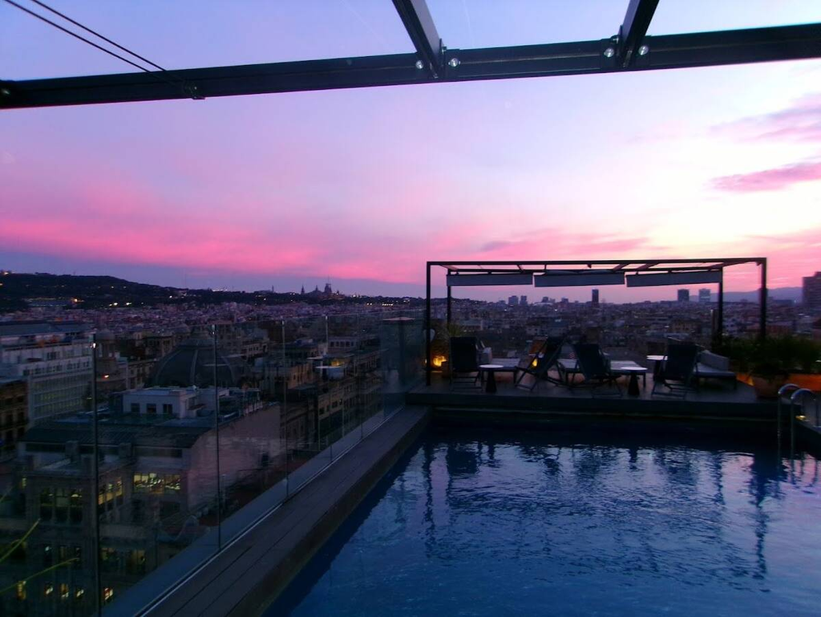

Barcelona · Madrid · 2026

# Two Cities. Two Lads. One *Definitive* Guide.

79 personally validated Barcelona spots. Study-abroad Madrid knowledge. Three versions for every type of trip. Built by people who actually live this.

Quick Read

## Spain at a glance

Best windows: late April or September post-Labor Day. Summer works but Barcelona gets crowded and hot. Avoid August if possible — half of Spain is on holiday.

**Budget:** $2,000–$3,200 per person (group of 4). Flights from ORD.

The Decision

## Barcelona vs. Madrid — *Honestly*

Two cities. Two completely different energies. This is not a travel blog hedging its bets. This is what we actually think, based on personal experience in both.

| Category | Barcelona | Madrid |
| --- | --- | --- |
| Nightlife | Beach clubs and speakeasies. Paradiso is world-class. More visual, more international. Shuts down earlier than you'd expect. Scene | Starts at 2am, doesn't stop. Kapital is seven floors of chaos. The city genuinely never sleeps. More local, more endurance-based. Edge: Madrid |
| Food Value | Cutting-edge culinary scene but pricier. Can Paixano is the best cheap cava in Europe. Tapas culture is strong but slightly touristified in the centre. Different strengths | Better traditional value. La Latina on a Sunday is unbeatable. Menú del día culture runs deeper. Your euro goes further here. Edge: Madrid |
| Architecture | Gaudí. The Sagrada Família interior will change how you think about buildings. Casa Batlló, Park Güell, the Gothic Quarter. Nothing else in Europe competes. Edge: Barcelona | Grand boulevards, the Bernabéu, Retiro Park. Impressive but conventional. The Golden Triangle museums are world-class if you're into art. Solid |
| Walkability | Flat grid in Eixample, compact old city. You can walk everywhere meaningful in a day. Beach access on foot. Edge: Barcelona | Hilly. Spread out. Metro is essential for anything beyond your barrio. But the metro is cheap and excellent. Fine with metro |
| Vibe | International, Mediterranean, visually overwhelming. Beach and mountains in the same day. A city that photographs itself. The postcard | Intensely Spanish. Social stamina. Plaza culture that pulls you in. Less pretty, more soulful. You'll fall in love with it unexpectedly. The feeling |
| Football | Camp Nou under renovation — capacity limited to ~60K. Tickets are extremely hard to get for big matches. Museum worth it for fans. Harder access | Bernabéu is 85K+ and fully operational. Easier to get tickets. The stadium itself is now a world-class entertainment complex. Edge: Madrid |
| Day Trips | Montserrat (10/10). Girona. Tossa de Mar. Sitges. All within 30-60 minutes. The day trip game is elite. Edge: Barcelona | Segovia (Roman aqueduct, 30 min). Toledo (medieval, 30 min). Both excellent but fewer options overall. Strong pair |
| Cost | ~15% more expensive across the board. Accommodation, drinks, attractions — all run higher than Madrid. Premium | Better value. Cheaper accommodation, cheaper drinks, cheaper food. Your budget stretches further. Edge: Madrid |

Brady

If you only have one week and you want to be overwhelmed in the best possible way — Barcelona. It's the most visually extraordinary city I've ever spent time in. The architecture alone justifies the trip. Add the food, the bars, the day trips, and you're looking at one of the best weeks of your life.

Dawson

Madrid is the city that surprises people. Nobody goes to Madrid expecting it to be their favourite, and then it is. The nightlife is on another level — I mean actually another level, it starts when Barcelona is going to sleep. If your group is here for the social energy and the football, Madrid might be the move.

Barcelona · Brady's City

## 79 Validated Spots. *One City That Earned Every One.*

Brady lived in Barcelona. Not visited — lived. Study abroad in Eixample, six weeks of building a mental map of every neighbourhood, every bar, every corner worth turning. This section is built on that knowledge, cross-referenced against 79 personally validated spots in our database. When we say we know Barcelona, this is what we mean.

[figure not shown]

Sagrada Família interior · The stained glass alone is worth the flight

Brady

The inside of the Sagrada Família is the single most beautiful thing I've seen anywhere in the world. I don't say that lightly. I've been to a lot of places. Nothing prepares you for what the light does in that building. Book morning tickets — the sunrise side stained glass turns the whole interior into this. Go early, go sober, go ready to just stand there for a while.

Architecture

## The Gaudí Circuit — *What to Pay For*

Barcelona has the most distinctive architectural identity of any city in Europe. But the ticket prices add up fast. Here's what's worth the money and what you can experience from the outside.

[figure not shown]

Must-Enter (Book Ahead)

Sagrada Família

The non-negotiable. Book tower access at least 3 weeks ahead. Morning tickets for the best stained glass light. Interior is life-changing. Exterior is a bonus.

€26+

4.8★ (318K)

Park Güell

Famous mosaics, panoramic views. Pre-booked entry required for the monumental zone. Go early morning to beat the crowds. The bench is the mandatory group photo.

€10

4.4★ (230K)

Palau de la Música Catalana

UNESCO concert hall. The interior is extraordinary — one of the most ornate rooms in Europe. Worth booking a guided tour or catching a performance.

€22

4.7★ (53K)

Worth the Ticket

Casa Batlló

Gaudí's dragon house. Interior is spectacular but expensive. Budget-conscious option: view the facade from Passeig de Gràcia for free and redirect the €35 toward dinner.

€35+

4.7★ (200K)

Recinte Modernista de Sant Pau

UNESCO site. Less crowded than the Gaudí marquee spots. Beautiful Modernist hospital complex — genuinely underrated.

€16

4.6★ (60K)

Free & Unmissable

Bunkers del Carmel

Best free 360° sunset view in the city. Bring a beer. Sit on the old Civil War bunkers and watch Barcelona turn gold. This is the moment.

Free

4.7★

Basílica de Santa Maria del Mar

Gothic. Free mornings. More powerful than the Cathedral. The interior scale is staggering — this is the church the locals prefer.

Free mornings

4.7★ (39K)

Magic Fountain of Montjuïc

Free light and music show Thu–Sun evenings. Cheesy in the best way. Go with a group and a beer from the corner shop.

Free

4.6★ (88K)

Gothic Quarter

Medieval heart of Barcelona. Best explored by wandering without a plan. You'll find more in 30 minutes of getting lost than any guided tour will show you.

Free

Where to Stay

## *Neighbourhood* Intelligence

Where you base the group determines everything — the daily friction, the walk home at 3am, the coffee spot you default to every morning. Get this right.

Eixample

Wide avenues, Cerdà grid, safe at all hours. Walking distance to Sagrada Família and Passeig de Gràcia. High concentration of craft beer bars ("Beerxample"). The pragmatic, smart base for a group. Brady stayed at U232 Hotel here.

El Born & Gothic Quarter

Medieval streets, speakeasy bars, Paradiso around the corner. You're in the thick of it. Trade-offs: narrow streets, noise, pickpocket activity at its highest. Smaller apartments. Worth visiting daily, not necessarily sleeping in.

Gràcia

Village-within-a-city energy. Plaça del Sol for authentic Catalan social life. Best vintage shopping in the city. Further from the beach, more metro-dependent. For groups that want the local experience over the tourist experience.

Las Ramblas

No. Primary pickpocket target. Overpriced food, poor quality. Every specialist says the same thing: don't stay here, don't eat here. Walk through it once and move on.

Food & Drink

## The Tapas Bars, the Speakeasies, *the Real List*

79 bars and restaurants in our database. Here are the ones that define Barcelona — the places Brady goes back to, the spots that made the cut after dozens of nights in this city.

Speakeasies & Cocktail Bars

World's Best

Paradiso

#4 World's Best Bars. Hidden behind a fridge door in a pastrami shop in El Born. The cocktails are theatrical, the entry is ridiculous, and it lives up to the hype.

€10–20

4.3★

Brady Pick

Bobby's Free

1920s speakeasy hidden inside a barber shop. Ask for the entrance. Dark wood, amber cocktails, the kind of place that makes you lower your voice.

€10–20

4.6★

Brady Pick

Mariposa Negra

Intimate cocktail bar. Consistently excellent drinks, no gimmicks, no queues. The kind of place you end up staying longer than planned.

€10–20

4.8★

The Alchemix

Highest-rated cocktail bar in the database at 4.8 stars. Chemistry-themed mixology done without pretension.

€10–20

4.8★

Kahiki Barcelona

Tiki cocktail bar. When you need a break from vermouth and cava. Fun, colourful, completely different energy from the speakeasy circuit.

€10–20

4.7★

Bars & Pubs

Brady Pick

Seven Under Bar

One of the highest-rated bars in Barcelona. The kind of local spot that doesn't need to advertise.

€10–20

4.8★

Brady Pick

Le Cyrano

Budget gem. Under €10 drinks in a city where that's increasingly rare. Good atmosphere, no pretension.

€1–10

4.4★

Tehran Bar

The highest-rated bar in the entire Barcelona database. 4.9 stars. That's not a typo.

€10–20

4.9★

El Xampanyet

Old-school cava bar in El Born. Cava and anchovies at the bar. The kind of place that hasn't changed in decades and shouldn't.

€10–20

Food — The Essential List

Brady Pick

Can Paixano (La Xampanyeria)

Standing-room cava bar. House sausage sandwiches and cheap cava at the counter. Loud, crowded, chaotic, perfect. The single best cheap meal-and-drink experience in Barcelona.

€10–20

Brady Pick

Bo de B

Legendary baguette sandwiches in El Born. Under €10. The kind of sandwich that makes you rethink lunch.

€1–10

Brady Pick

COMPÀ

Gràcia. Panino Calabrese. Simple, exceptional, worth the walk up from the centre.

€10–20

Bar Tomàs

Best patatas bravas in Barcelona. Sarrià. Worth the metro ride for this alone.

€1–10

Cal Pep

Standing-bar tapas legend. Baby squid and clams. The bartenders run the show and they know what you should order.

€20–30

Cervcería Catalana

Montaditos and tapas in Eixample. Reliable, always good. The kind of place you default to and never regret it.

€10–20

Mercat de Santa Caterina

The local alternative to Boqueria. Less touristy, better prices, better energy. Actually functions as a market, not a selfie backdrop.

€1–10

Vintage & Shopping

Brady Pick

Hand Of God

Independent football jersey shop — rare and retro kits. If you care about football shirts, this is the stop.

4.7★

Il Capo Vintage (El Born + El Raval)

Two locations, both worth checking. Curated, well-priced. The Born branch is the flagship.

4.8–5.0★

VNTG24 Vintage

Perfect 5.0-star rating. Small, curated. The kind of shop where you find one piece and it becomes your favourite thing you own.

5.0★

Mercat dels Encants

Massive open-air flea market under a mirrored canopy at Glòries. Chaotic but fun. The kind of place that rewards patience.

4.3★

Day Trips

## Beyond the City — *The Ones Worth Leaving For*

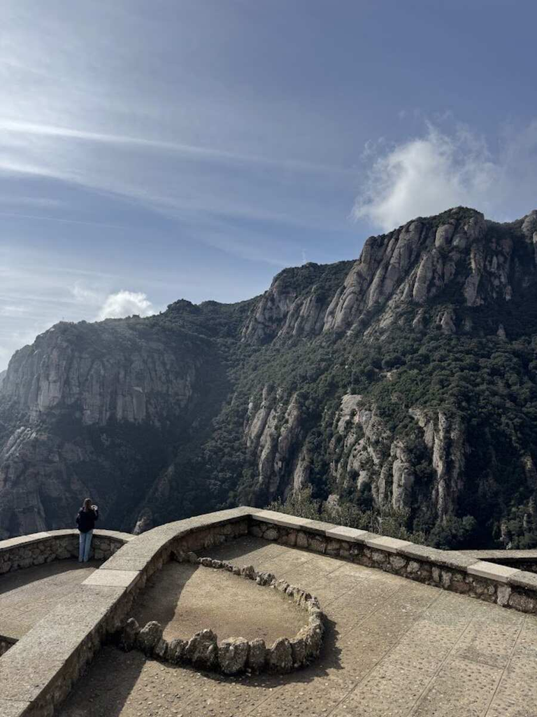

Montserrat · Brady rated 10/10

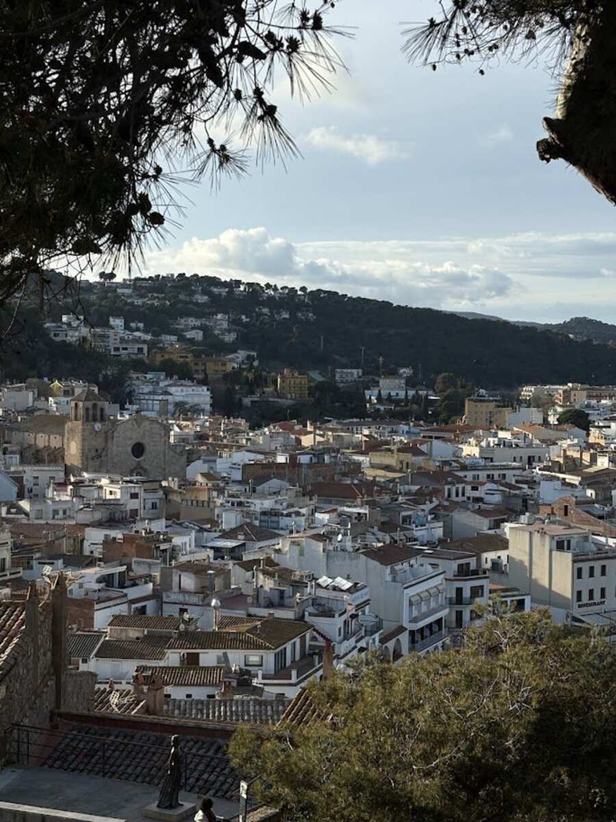

Tossa de Mar · From the fortress walls

Brady

The Montserrat + Girona + Tossa de Mar day trip circuit is a 10/10. I'm friends with a tour guide who does this route. Montserrat is unlike anything you've seen — the monastery sits in these jagged, impossible rock formations. Girona is medieval Game of Thrones territory. And Tossa de Mar is the coastal town you didn't know you were looking for. Do this trip.

Montserrat

Jagged mountain range with a Benedictine monastery. R5 train from Plaça d'Espanya + cable car or rack railway. Insane views. Deep cultural experience. Half-day minimum.

~€25 transport

Girona

Medieval city, Game of Thrones filming location. 38-minute AVANT train from Barcelona. Viable as a half-day for architecture and history. Bagels & Beers for a pint after exploring.

~€12 train

Sitges

30 minutes south by train. Refined beach town with beautiful coves. Perfect one-day escape from the city's intensity. More upscale than Barceloneta.

~€6 train

[Book: Montserrat + Girona + Sitges Full-Day Tour →](https://www.viator.com/tours/Barcelona/From-Barcelona-Montserrat-Girona-and-Sitges-Full-Day-Tour/d562-6874P164)

Barcelona Only · 7 Days

## What It *Actually* Costs

Per-person estimates based on a group sharing mid-to-high-tier accommodation and using the menú del día strategy. Flights from ORD.

Lean Spend

$1,540

Flights $650  
Accommodation $350  
Food & Drink $350  
Activities $150  
Transport $40

Standard Spend

$2,280

Flights $850  
Accommodation $550  
Food & Drink $500  
Activities $300  
Transport $80

Generous Spend

$3,650

Flights $1,200  
Accommodation $900  
Food & Drink $800  
Activities $600  
Transport $150

Estimates based on 2026 projections. Football tickets not included in standard — add $300–$500 per person for a match. Group of 4 sharing accommodation achieves the best per-person rate.

Barcelona + Madrid · 10–14 Days

## Both Cities. *Both Lads.* The Full Iberian Experience.

Fly into Barcelona, train to Madrid, fly home. Open-jaw ticket costs the same as a round trip. You get Brady's Barcelona for the first week and Dawson's Madrid for the second. Two different cities, two different energies, one trip that covers everything Spain has to offer a group of guys in their 20s.

Brady

The combo version is the move if you have the time. Barcelona hits you with the visuals — the Gaudí, the beach, the speakeasies — and then Madrid shifts the energy completely. By the time you're on that train to Madrid, you think you've already had the best week of your life. Then Dawson's city surprises you.

Dawson

Starting in Barcelona is the right call. It's the higher-intensity city visually, and you want that energy at the front of the trip. Madrid is where you settle in. The nightlife runs later, the food is cheaper, the plazas pull you outside. It's a different kind of good — less photogenic, more felt.

The Route

**Days 1–6:** Barcelona. High intensity — architecture, beach, speakeasies, day trips. Land running.  
**Day 7:** Morning Iryo train to Madrid (2.5 hours, Barcelona Sants → Madrid Atocha).  
**Days 8–12:** Madrid. Social endurance — La Latina tapas, Kapital, Retiro Park, day trips to Segovia or Toledo.

The Train

**Iryo** is the specialist recommendation. Newest trainsets in Spain, Frecciarossa 1000 Italian rolling stock, XXL leather seats, 5G Wi-Fi, and food service (Haizea) that's actually good. Book "Mesa" seating — four seats around a table. **Ouigo** is the budget option (potentially €9 per person if booked 60+ days out), but it's cramped and the luggage policy is strict. **Book 30+ days ahead** to save up to 60% versus walk-up fares.

The Flight

**Open-jaw:** ORD → BCN, then MAD → ORD. Same price as a round trip to either city. Saves you a return train and gains half a day. **Direct from ORD:** American, United, and Iberia all fly direct to both cities (~8.5 hours). **From DTW:** No direct flights — connect through JFK, PHL, or European hubs. Sometimes $100 cheaper but adds 3–5 hours.

For the full Barcelona section, switch to the Barcelona tab above. For the full Madrid section, switch to Madrid. The combo version includes everything from both — same spots, same detail, just a longer trip.

Barcelona + Madrid · 12 Days

## Combo Trip — *What It Costs*

Lean Spend

$2,240

Flights (Open-Jaw) $700  
Accommodation $650  
Food & Drink $600  
AVE Train $40  
Activities (2 Cities) $250

Standard Spend

$3,330

Flights (Open-Jaw) $900  
Accommodation $950  
Food & Drink $900  
AVE Train $80  
Activities (2 Cities) $500

Generous Spend

$5,250

Flights (Open-Jaw) $1,300  
Accommodation $1,500  
Food & Drink $1,400  
AVE Train $150  
Activities (2 Cities) $900

Open-jaw pricing is essentially free — same cost as round-trip. The AVE/Iryo train is the best transport value in Europe. Book flights 4–6 months ahead; train 30–60 days ahead.

Madrid · Dawson's City

## The City That *Surprises* Everyone.

Dawson studied abroad in Madrid. Not a semester of classes with a weekend trip — months of learning how the city actually works from the inside. The late-night rhythm, the barrio boundaries, the places that only exist because someone who lives there showed him. This section is built on that knowledge.

[figure not shown]

Santiago Bernabéu · Personally validated

Dawson

Madrid is the city people don't expect to love. It doesn't have the beach. It doesn't have Gaudí. What it has is an energy that doesn't quit — the plazas fill up at 10pm and don't empty until the sun comes up. The football is world-class and the tickets are actually gettable. The food value is better than Barcelona. And the nightlife starts at an hour that would be last call anywhere else in Europe.

Culture & Sights

## The Golden Triangle *& Beyond*

[figure not shown]

Puerta del Sol · Madrid doesn't stop at midnight

The Essentials

Prado Museum

Focus on the hits: Velázquez's Las Meninas and Goya's Black Paintings. Free entry in the last two hours of the day but the queues are immense — a paid ticket is a better investment of time for a group.

€15

Reina Sofía

Home to Picasso's Guernica. Essential viewing. One of the most powerful paintings in the world, and the room is designed around it.

€12

Retiro Park

Madrid's green lungs. Free. Row a boat on the lake, find the Crystal Palace, people-watch for hours. The perfect afternoon when you need to recharge before the nightlife starts.

Free

Santiago Bernabéu

More than a stadium — it's a fully integrated entertainment complex. 85,000+ capacity means tickets are more obtainable than Camp Nou. The Bernabéu Tour is worth it even if you can't get match tickets.

$300–500 match

Dawson

Temple de Debod at sunset. It's an actual Egyptian temple in a Madrid park, gifted by Egypt in 1968. You stand there watching the sun go down behind the Royal Palace and it's one of the most surreal, beautiful things in the city. Free. Barely any tourists compared to everything else. This is the spot.

Nightlife

## Starts at 2am. *Not a Figure of Speech.*

Madrid nightlife is an endurance sport. If you arrive at a club before 1:30am, you're the only one there. The city operates on a different clock — dinner at 10pm, drinks at midnight, clubs at 2am, home at sunrise. This is Dawson's domain.

The Nightlife Circuit

Lads Tier

Teatro Kapital

Seven floors in a former theater. Main room for EDM, another for karaoke, another for reggaeton, rooftop for cocktails. Strict dress code — no trainers or sportswear. Arrive after 1am. This is the Madrid clubbing experience.

€15–20 entry

Círculo de Bellas Artes (Rooftop)

Best skyline rooftop bar in Madrid. Entry fee or premium drinks, but the 360° views are worth it for a sunset session before the real night begins.

€5 entry + drinks

Mercado de San Antón (Rooftop)

Chueca. Market below, rooftop bar above. A good early-evening move before the real nightlife starts. Food and drinks with a view.

€10–20

Dawson

Kapital at 2am on a Saturday is a different planet. You walk through the door and there are seven floors of completely different music. You'll end up in the karaoke room at 4am wondering how you got there. Wear decent shoes — they will turn you away in trainers. This is non-negotiable Madrid.

Where to Stay

## *Barrio* Intelligence

Malasaña

The hipster heart. Former epicentre of the Movida Madrileña. Vintage fashion, indie bookstores, edgy bars around Plaza del Dos de Mayo. The most compatible base for a group of 20-something guys. Best nightlife access.

La Latina

The tapas capital. Narrow medieval streets. Sunday El Rastro flea market followed by an epic tapas crawl on Calle de Cava Baja. Classic Madrid. The "right" Sunday in La Latina is the best day you'll have.

Chueca

Vibrant, inclusive, high-energy. Excellent dining at Mercado de San Antón. Sophisticated rooftop bar scene. One of the most welcoming neighbourhoods in any European capital.

Salamanca

High-end shopping and luxury dining. Beautiful but can feel pijo (posh) compared to Malasaña or La Latina. Visit for a dinner. Stay somewhere with more energy.

Critical Note — Summer Travel

If visiting Madrid in summer, air conditioning is **non-negotiable** in your accommodation. Many older buildings in La Latina and the centre lack central cooling. Madrid regularly exceeds 40°C (104°F) in July and August. Check the listing before you book.

Day Trips

## Segovia & Toledo — *30 Minutes Each*

Dawson Validated

Segovia

Perfectly preserved Roman Aqueduct and the Alcázar castle (the one that inspired the Disney castle). 30-minute high-speed train. Easy full day with lunch — the roast suckling pig is famous here.

~€12 train

Dawson Validated

Toledo

UNESCO "City of Three Cultures" — Christian, Jewish, and Muslim heritage layered in medieval streets. 30 minutes from Madrid. A maze of history you could spend all day in.

~€14 train

Dawson

Both are 30-minute trains and both are worth a full day. Segovia's aqueduct is genuinely jaw-dropping — it's 2,000 years old and just sitting there in the middle of a modern city. Toledo feels like stepping into a different century. If you only have time for one, Segovia edges it for the visual impact.

Madrid Only · 7 Days

## What It *Actually* Costs

Lean Spend

$1,370

Flights $620  
Accommodation $300  
Food & Drink $300  
Activities $120  
Transport $30

Standard Spend

$2,060

Flights $820  
Accommodation $480  
Food & Drink $450  
Activities $250  
Transport $60

Generous Spend

$3,320

Flights $1,150  
Accommodation $800  
Food & Drink $750  
Activities $500  
Transport $120

Madrid is ~15% cheaper than Barcelona across the board. From DTW: no directs, but connecting through JFK or European hubs can save ~$100. Football tickets: Bernabéu 85K capacity makes standard matches more accessible than Camp Nou.

Ways to Save

## Spend Smart, *Not Less*

Spain is a country where intelligence beats austerity. The difference between a $1,500 trip and a $3,000 trip isn't quality — it's knowledge.

The Single Best Financial Move in Spain

The Menú del Día

Spanish restaurants offer a fixed-price three-course lunch including a drink and bread. This is not a tourist deal — it's legally mandated and culturally embedded. A proper restaurant lunch that would cost €35–50 at dinner is €12–18 at midday. Both lads swear by this. Eat a big menú del día lunch, then do tapas hopping for a light dinner. Your food budget drops by a third and you eat better.

€12 – €18 per person · 3 courses + drink + bread

Brady

The menú del día changed how I eat in Spain. You walk into a proper restaurant at 1pm and get three courses, wine, bread — for fifteen euros. Then at night you're free to just do tapas at the bar. Standing, cheap, fast. The money you save here pays for the speakeasy cocktails later.

Dawson

Same. The menú del día is the hack. In Madrid it runs even cheaper than Barcelona — €12–14 for a proper meal. And at tapas bars, stand at the bar instead of sitting at a table. It's cheaper, the service is faster, and the bartenders respect you more.

More Smart Moves

The Mercadona Strategy

Spain's leading supermarket. Hacendado private-label wine and spirits are genuinely high quality for the price. Stock the apartment for pre-games and park picnics in Retiro. **Saves hundreds of euros** versus buying every drink at a bar.

Standing vs. Seated

In traditional tapas bars, standing at the bar is cheaper than sitting at a table or terrace. It's also faster, more authentic, and the bartenders take you more seriously.

Tipping

Not mandatory. 5–10% for good service is generous. At a casual bar, round up to the nearest euro. Don't apply American tipping norms — you'll confuse the staff.

Always Pay in Euros

If a card machine asks USD or EUR, **always choose EUR**. Choosing USD triggers Dynamic Currency Conversion — a hidden 3–5% fee. For connectivity, an eSIM (Yesim or Airalo) beats an airport SIM card on price and convenience.

Book Smart

**Flights:** 4–6 months ahead for the best fares. **Trains:** 30–60 days ahead for up to 60% savings. **Sagrada Família:** 3+ weeks ahead. **Football:** As early as possible — Camp Nou's limited capacity makes secondary market prices brutal.

When to Go

## The *Timing* Window

| Window | Weather | Crowds | Key Events | Verdict |
| --- | --- | --- | --- | --- |
| Spring Apr – May | BCN 62°F / MAD 60°F. Perfect walking weather. | High — Semana Santa + football season climax. | Semana Santa, La Liga title race, Champions League knockouts. | Great for football |
| Summer Jun – Aug | BCN 82°F / MAD 95°F+. Madrid is an oven. | Peak. Barcelona overtourism at worst. | San Fermín (Pamplona, Jul 6–14). Beach season. | Avoid unless beach-only |
| Autumn Sep – Oct | BCN 70°F / MAD 68°F. Warm sea, cool air. | Moderate. Locals return, tourists thin out. | La Mercè (BCN, Sep 23–27). Football season kickoff. | The Sweet Spot |

The Recommendation

**September 15 – October 5** is the definitive window. You avoid the Madrid heat, the Barcelona summer crowds, and you catch La Mercè (Barcelona's biggest street festival — free concerts, fire runs, human towers) plus the start of the football season. The Mediterranean is still at its warmest annual temperature. Book flights in April or May for the best rates.

What First-Timers Get Wrong

### 2. Eating at La Boqueria

The market itself is worth seeing. The food stalls inside are tourist traps charging double for half portions. Eat at the restaurants in El Born or Barceloneta instead.

### 3. Tipping American-style

Spain does not have a tipping culture. Rounding up or leaving a euro on a coffee is plenty. Leaving 20% marks you as a tourist and does not improve your service.

### 5. Skipping Montserrat

The mountain monastery is one hour from Barcelona and turns a city trip into a multi-destination experience. The views alone justify the day. Book the full-day tour that includes Girona and Sitges.

Your Maps

## Google Maps Lists

Every spot in this framework, pinned and organized. Open on your phone when you land.

[Barcelona Food →](https://maps.app.goo.gl/bZp95gDP9VwBe6Kd7) [Barcelona Bars →](https://maps.app.goo.gl/2LZGLZQEuT53NK3Z8) [Barcelona Attractions →](https://maps.app.goo.gl/63o5dgY5Fr8SJUZk6)

MORE FRAMEWORKS

Italy Prague + Vienna Dublin + Galway